# scratch

Christine Gao

2/20/2023

## Sanity checks for WS RNAseq +/- GSKJ4

### Comparing to first RNAseq

Load the results table from the 1st RNAseq (Mut vs WT).

```r
setwd("~/Desktop/temp/Fahrner lab/Data/Weaver/fahrner_weaver/RNAseq/final_analysis/BigStuff")
load(file='dds_final.rda')
res.old <- results(dds)
```

Load the results table from the 2nd RNAseq, calling contrast between MutDMSO and WtDMSO.

```r
setwd("~/Desktop/temp/Fahrner lab/Data/Weaver/fahrner_weaver/RNAseq/final_analysis")
load(file='dds_collapsed_GSKJ4.rda')
res.MutDMSO.WtDMSO <- results(dds, contrast = list(c('genotype_Mut_vs_WT')))
```

Most genes should exist in both datasets. Keep only the genes that exist in both and plot the corresponding log2FC. Highlight genes that are significant at padj<0.1 in both datasets.

```r
table(rownames(res.old) %in% rownames(res.MutDMSO.WtDMSO))
```

```
##
## FALSE  TRUE
##   382 13841
```

```r
intersect.old <- res.old[which(rownames(res.old) %in% rownames(res.MutDMSO.WtDMSO)==TRUE),]
intersect.MutDMSO.WtDMSO <- res.MutDMSO.WtDMSO[which(rownames(res.MutDMSO.WtDMSO) %in% rownames(res.old)==TRUE),]
tab <- data.frame(log2FC.1=intersect.old$log2FoldChange, log2FC.2=intersect.MutDMSO.WtDMSO$log2FoldChange)
rownames(tab) <- rownames(intersect.old)

gene_ids.old <- rownames(intersect.old[which(intersect.old$padj<0.1),])
gene_ids.MutDMSO.WtDMSO <- rownames(intersect.MutDMSO.WtDMSO[which(intersect.MutDMSO.WtDMSO$padj<0.1),])
gene_ids <- gene_ids.old[gene_ids.old %in% gene_ids.MutDMSO.WtDMSO]
#gene_ids <- union(gene_ids.old, gene_ids.MutDMSO.WtDMSO)

setEPS()
postscript('plots_final/log2FC_untreated_MutDMSO.WtDMSO_sig-only.eps')
plot(intersect.old$log2FoldChange, intersect.MutDMSO.WtDMSO$log2FoldChange,
     pch=16, cex=0.75, col=alpha('gray50',0.5),
     xlim=c(-4,3), ylim=c(-4,4),
     xlab='log2FC, D14 Mut vs Wt', ylab='log2FC, D21 MutDMSO vs WtDMSO')
points(tab[gene_ids, ], pch = 16, cex = 0.75, col ='orange')
abline(h=0, v=0, col='red', lty=2)
dev.off()
```

Mark the genes that 1. exist in both datasets, and 2. are significantly differentially expressed in the old dataset (Mut vs WT).

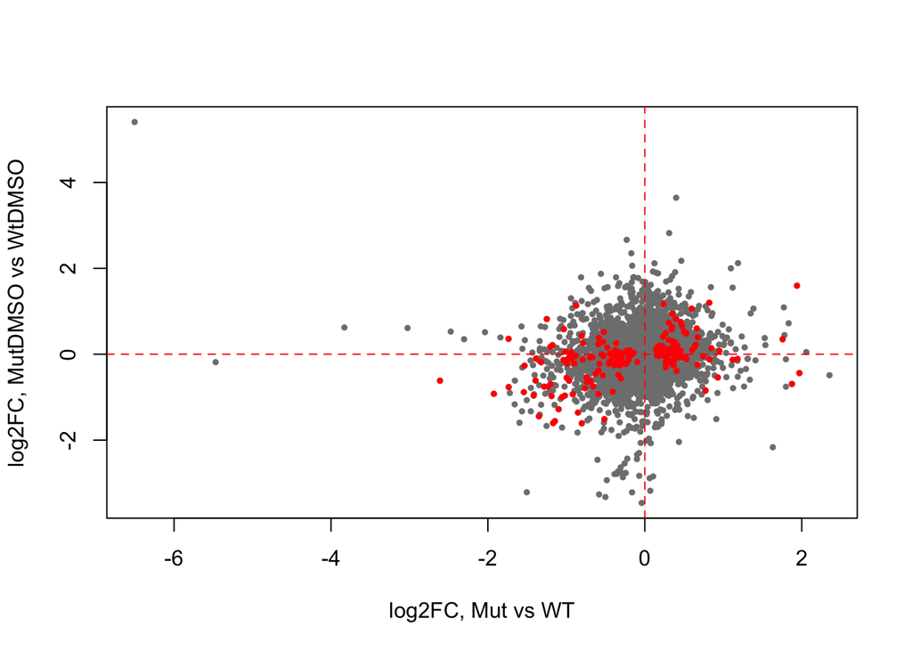

```r
plot(intersect.old$log2FoldChange, intersect.MutDMSO.WtDMSO$log2FoldChange,
     pch=19, cex=0.5, col='gray50',
     xlab='log2FC, Mut vs WT', ylab='log2FC, MutDMSO vs WtDMSO')
points(tab[gene_ids.old, ], pch = 19, cex = 0.5, col ='red')
abline(h=0, v=0, col='red', lty=2)
```

Mark the genes that 1. exist in both datasets, and 2. are significantly differentially expressed in the MutDMSO vs WtDMSO dataset.

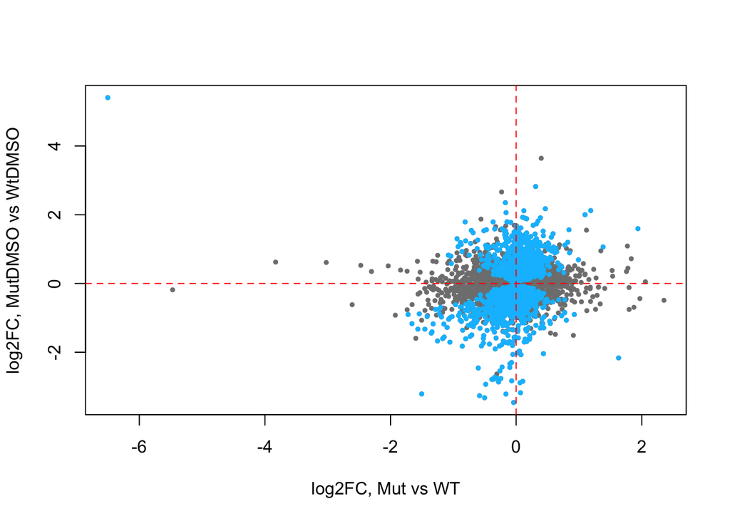

```r
plot(intersect.old$log2FoldChange, intersect.MutDMSO.WtDMSO$log2FoldChange,
     pch=19, cex=0.5, col='gray50',
     xlab='log2FC, Mut vs WT', ylab='log2FC, MutDMSO vs WtDMSO')
points(tab[gene_ids.MutDMSO.WtDMSO, ], pch = 19, cex = 0.5, col ='deepskyblue')
abline(h=0, v=0, col='red', lty=2)
```

Overlay all 3 plots

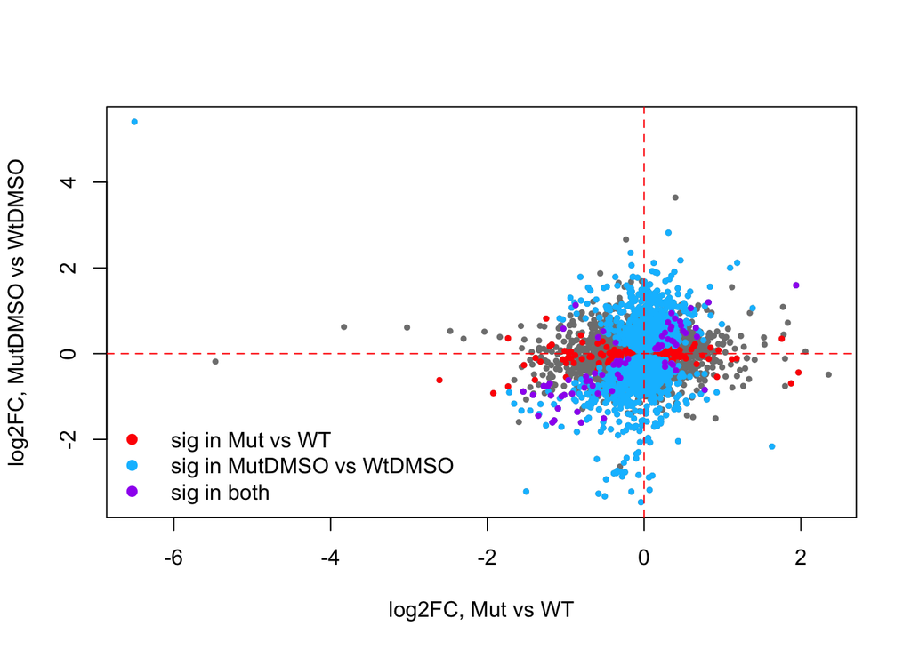

```r
plot(intersect.old$log2FoldChange, intersect.MutDMSO.WtDMSO$log2FoldChange,
     pch=19, cex=0.5, col='gray50',
     xlab='log2FC, Mut vs WT', ylab='log2FC, MutDMSO vs WtDMSO')
points(tab[gene_ids.old, ], pch = 19, cex = 0.5, col = 'red')
points(tab[gene_ids.MutDMSO.WtDMSO, ], pch = 19, cex = 0.5, col = 'deepskyblue')
points(tab[gene_ids, ], pch = 19, cex = 0.5, col ='purple')
abline(h=0, v=0, col='red', lty=2)
legend <- legend('bottomleft', legend=c('sig in Mut vs WT','sig in MutDMSO vs WtDMSO','sig in both'),
                   col=c('red','deepskyblue','purple'), lty=c(NA,NA,NA), pch=c(19,19,19), lwd=c(NA,NA,NA), cex=1, bty='n')
```

Note that there are much fewer significant genes in the 1st RNAseq.

```r
table(gene_ids.old %in% gene_ids.MutDMSO.WtDMSO)
```

```
##
## FALSE  TRUE
##   116    74
```

```r
table(gene_ids.MutDMSO.WtDMSO %in% gene_ids.old)
```

```
##
## FALSE  TRUE
##  2577    74
```

Check the expression level (mean counts) in Wt and WtDMSO samples. Overall they appear correlated.

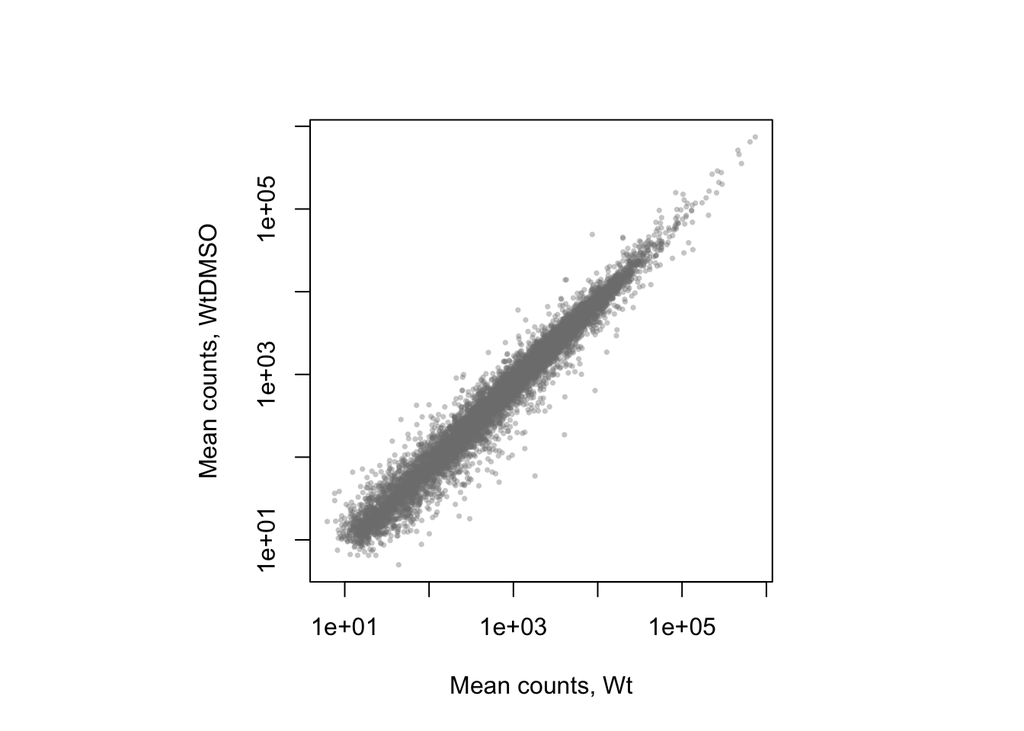

```r
setwd("~/Desktop/temp/Fahrner lab/Data/Weaver/fahrner_weaver/RNAseq/final_analysis/BigStuff")
load(file='dds_final.rda')
counts.Wt <- counts(dds)[,dds$condition=='WT']

setwd("~/Desktop/temp/Fahrner lab/Data/Weaver/fahrner_weaver/RNAseq/final_analysis")
load(file='dds_collapsed_GSKJ4.rda')
counts.WtDMSO <- counts(dds)[,dds$genotype=='WT' & dds$tx=='DMSO']

intersect.counts.Wt <- counts.Wt[rownames(counts.Wt) %in% rownames(counts.WtDMSO),]
intersect.counts.WtDMSO <- counts.WtDMSO[rownames(counts.WtDMSO) %in% rownames(counts.Wt),]

par(pty='s')
plot(apply(intersect.counts.Wt,1,mean), apply(intersect.counts.WtDMSO,1,mean), log='xy',
     pch=16, cex=0.5, col=alpha('gray50', 0.4),
     xlab='Mean counts, Wt', ylab='Mean counts, WtDMSO')
```

Plot the histogram of MutDMSO vs WtDMSO p-values for the 190 genes that were differentially expressed in the Mut vs Wt dataset

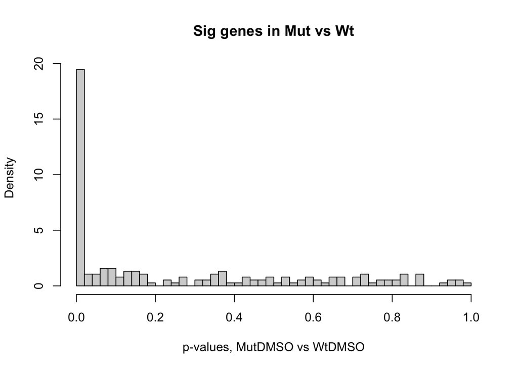

```r
hist(res.MutDMSO.WtDMSO[rownames(intersect.old[intersect.old$padj<0.1,]),]$pvalue,
     breaks=40, freq=FALSE,
     xlab='p-values, MutDMSO vs WtDMSO', main='Sig genes in Mut vs Wt')
```

Plot the histogram of Mut vs Wt p-values for the 2651 genes that were differentially expressed in the MutDMSO vs WtDMSO dataset

```r
setEPS()
postscript('plots_final/pval-hist_D14_MutDMSO.WtDMSO.eps')
hist(res.old[rownames(intersect.MutDMSO.WtDMSO[intersect.MutDMSO.WtDMSO$padj<0.1,]),]$pvalue,
     breaks=40, freq=FALSE,
     xlab='p-values, D14 Mut vs Wt', main='Sig genes in D21 MutDMSO vs WtDMSO')
dev.off()
```

## Effect of GSKJ4 in Mut

```r
setwd("~/Desktop/temp/Fahrner lab/Data/Weaver/fahrner_weaver/RNAseq/final_analysis")
load(file='dds_collapsed_GSKJ4.rda')
res.MutGSKJ4.MutDMSO <- results(dds, contrast = list(c('tx_GSKJ4_vs_DMSO',
                                                       'genotypeMut.txGSKJ4')))
```

## Effect of GSKJ4 in Wt

```r
setwd("~/Desktop/temp/Fahrner lab/Data/Weaver/fahrner_weaver/RNAseq/final_analysis")
load(file='dds_collapsed_GSKJ4.rda')
res.WtGSKJ4.WtDMSO <- results(dds, contrast = list(c('tx_GSKJ4_vs_DMSO')))
```

How many genes that are differentially expressed due to GSKJ4 are shared between genotypes? (i.e. what is the general effect of the drug)

```r
diffexp.MutGSKJ4.MutDMSO <- as.data.frame(res.MutGSKJ4.MutDMSO[which(res.MutGSKJ4.MutDMSO$padj <0.1),])
diffexp.WtGSKJ4.WtDMSO <- as.data.frame(res.WtGSKJ4.WtDMSO[which(res.WtGSKJ4.WtDMSO$padj <0.1),])
table(rownames(diffexp.MutGSKJ4.MutDMSO) %in% rownames(diffexp.WtGSKJ4.WtDMSO))
```

```
##
## FALSE  TRUE
##  1879  1167
```

```r
table(rownames(diffexp.WtGSKJ4.WtDMSO) %in% rownames(diffexp.MutGSKJ4.MutDMSO))
```

```
##
## FALSE  TRUE
##  1085  1167
```

## ?Phenotype reversion in MutGSKJ4 to WtDMSO

```r
setwd("~/Desktop/temp/Fahrner lab/Data/Weaver/fahrner_weaver/RNAseq/final_analysis")
load(file='dds_collapsed_GSKJ4.rda')
res.MutGSKJ4.WtDMSO <- results(dds, contrast = list(c('genotype_Mut_vs_WT',
                                                       'tx_GSKJ4_vs_DMSO',
                                                       'genotypeMut.txGSKJ4')))
```

## P-value histograms

Comparing MutDMSO vs WtDMSO:

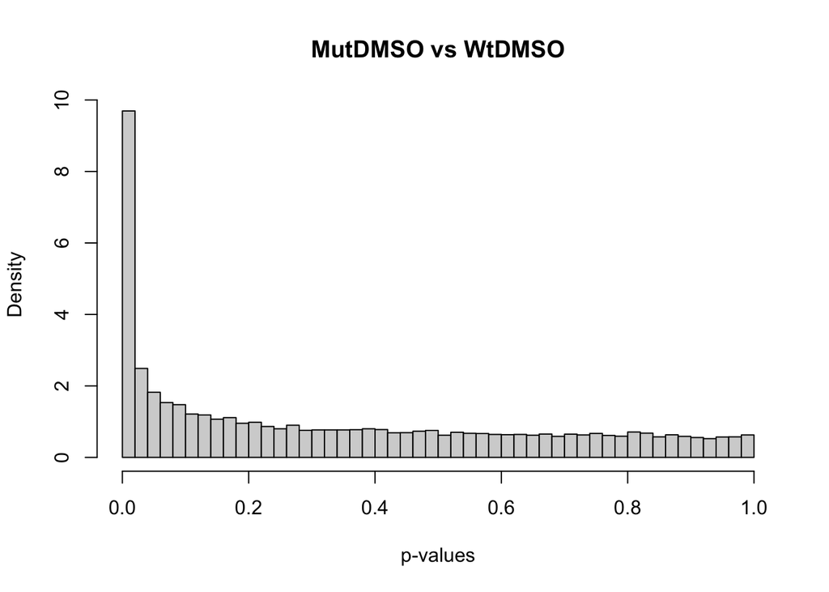

```r
hist(res.MutDMSO.WtDMSO$pvalue, freq=FALSE, breaks=40,
     xlab='p-values', main='MutDMSO vs WtDMSO')
```

Comparing MutGSKJ4 vs MutDMSO:

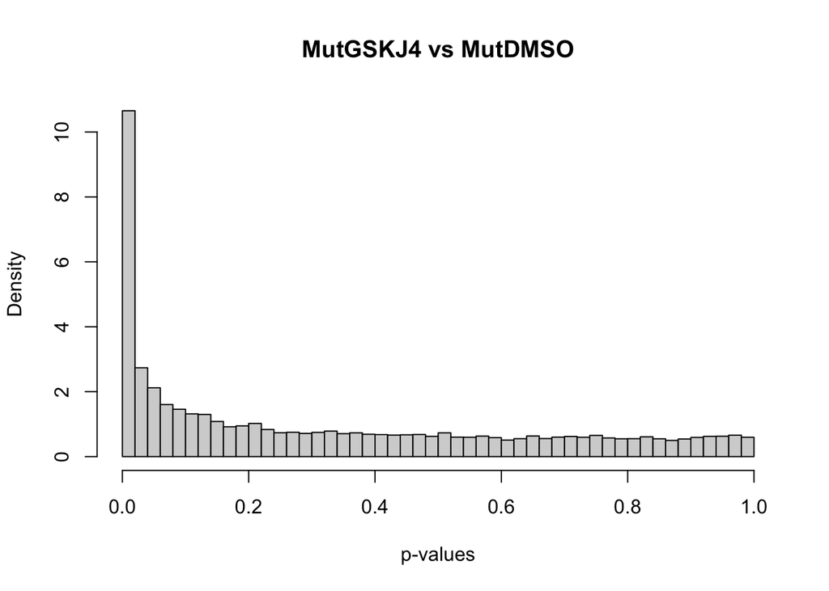

```r
hist(res.MutGSKJ4.MutDMSO$pvalue, freq=FALSE, breaks=40,
     xlab='p-values', main='MutGSKJ4 vs MutDMSO')
```

Comparing MutGSKJ4 vs WtDMSO:

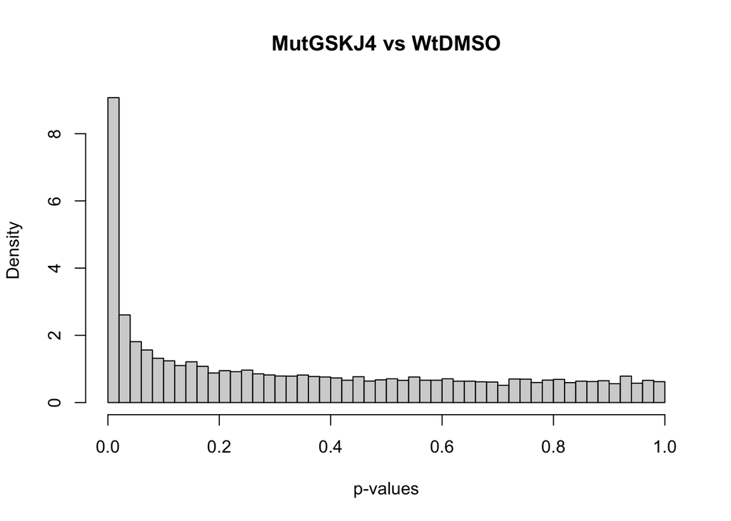

```r
hist(res.MutGSKJ4.WtDMSO$pvalue, freq=FALSE, breaks=40,
     xlab='p-values', main='MutGSKJ4 vs WtDMSO')
```